# Exercise 3

3. Read the file.

```r
college = read.csv("College.csv", header=T)
str(college)
```

```
'data.frame':   777 obs. of  19 variables:
 $ X          : Factor w/ 777 levels "Abilene Christian University",..: 1 2 3 4 5 6 7 8 9 10 ...
 $ Private    : Factor w/ 2 levels "No","Yes": 2 2 2 2 2 2 2 2 2 2 ...
 $ Apps       : int  1660 2186 1428 417 193 587 353 1899 1038 582 ...
 $ Accept     : int  1232 1924 1097 349 146 479 340 1720 839 498 ...
 $ Enroll     : int  721 512 336 137 55 158 103 489 227 172 ...
 $ Top10perc  : int  23 16 22 60 16 38 17 37 30 21 ...
 $ Top25perc  : int  52 29 50 89 44 62 45 68 63 44 ...
 $ F.Undergrad: int  2885 2683 1036 510 249 678 416 1594 973 799 ...
 $ P.Undergrad: int  537 1227 99 63 869 41 230 32 306 78 ...
 $ Outstate   : int  7440 12280 11250 12960 7560 13500 13290 13868 15595 10468 ...
 $ Room.Board : int  3300 6450 3750 5450 4120 3335 5720 4826 4400 3380 ...
 $ Books      : int  450 750 400 450 800 500 500 450 300 660 ...
 $ Personal   : int  2200 1500 1165 875 1500 675 1500 850 500 1800 ...
 $ PhD        : int  70 29 53 92 76 67 90 89 79 40 ...
 $ Terminal   : int  78 30 66 97 72 73 93 100 84 41 ...
 $ S.F.Ratio  : num  18.1 12.2 12.9 7.7 11.9 9.4 11.5 13.7 11.3 11.5 ...
 $ perc.alumni: int  12 16 30 37 2 11 26 37 23 15 ...
 $ Expend     : int  7041 10527 8735 19016 10922 9727 8861 11487 11644 8991 ...
 $ Grad.Rate  : int  60 56 54 59 15 55 63 73 80 52 ...
```

There are 777 observations and 19 variables.

```r
attach(college)
summary(college)
```

```
                            X       Private        Apps
 Abilene Christian University:  1   No :212   Min.   :   81
 Adelphi University          :  1   Yes:565   1st Qu.:  776
 Adrian College              :  1             Median : 1558
 Agnes Scott College         :  1             Mean   : 3002
 Alaska Pacific University   :  1             3rd Qu.: 3624
 Albertson College           :  1             Max.   :48094
 (Other)                     :771
     Accept          Enroll       Top10perc       Top25perc
 Min.   :   72   Min.   :  35   Min.   : 1.00   Min.   :  9.0
 1st Qu.:  604   1st Qu.: 242   1st Qu.:15.00   1st Qu.: 41.0
 Median : 1110   Median : 434   Median :23.00   Median : 54.0
 Mean   : 2019   Mean   : 780   Mean   :27.56   Mean   : 55.8
 3rd Qu.: 2424   3rd Qu.: 902   3rd Qu.:35.00   3rd Qu.: 69.0
 Max.   :26330   Max.   :6392   Max.   :96.00   Max.   :100.0

  F.Undergrad     P.Undergrad         Outstate       Room.Board
 Min.   :  139   Min.   :    1.0   Min.   : 2340   Min.   :1780
 1st Qu.:  992   1st Qu.:   95.0   1st Qu.: 7320   1st Qu.:3597
 Median : 1707   Median :  353.0   Median : 9990   Median :4200
 Mean   : 3700   Mean   :  855.3   Mean   :10441   Mean   :4358
 3rd Qu.: 4005   3rd Qu.:  967.0   3rd Qu.:12925   3rd Qu.:5050
 Max.   :31643   Max.   :21836.0   Max.   :21700   Max.   :8124

     Books           Personal         PhD            Terminal
 Min.   :  96.0   Min.   : 250   Min.   :  8.00   Min.   : 24.0
 1st Qu.: 470.0   1st Qu.: 850   1st Qu.: 62.00   1st Qu.: 71.0
 Median : 500.0   Median :1200   Median : 75.00   Median : 82.0
 Mean   : 549.4   Mean   :1341   Mean   : 72.66   Mean   : 79.7
 3rd Qu.: 600.0   3rd Qu.:1700   3rd Qu.: 85.00   3rd Qu.: 92.0
 Max.   :2340.0   Max.   :6800   Max.   :103.00   Max.   :100.0

   S.F.Ratio      perc.alumni        Expend        Grad.Rate
 Min.   : 2.50   Min.   : 0.00   Min.   : 3186   Min.   : 10.00
 1st Qu.:11.50   1st Qu.:13.00   1st Qu.: 6751   1st Qu.: 53.00
 Median :13.60   Median :21.00   Median : 8377   Median : 65.00
 Mean   :14.09   Mean   :22.74   Mean   : 9660   Mean   : 65.46
 3rd Qu.:16.50   3rd Qu.:31.00   3rd Qu.:10830   3rd Qu.: 78.00
 Max.   :39.80   Max.   :64.00   Max.   :56233   Max.   :118.00
```

How many private universities are there in the data? 565 private universities. What is the average graduation rate (Grad.Rate)? 65.46. What is the range of estimated book costs (range=maxValue-minValue)?

```r
bookCosts=2340.0-96.0
bookCosts
```

```
[1] 2244
```

4. The next task is to find out what is the highest value of variable Top10perc and to which University it is associated - the name of this University.

```r
college <- college[order(-college$Top10perc),]
college[1,]
```

|  | X | Private | Apps | Accept | Enroll | Top10perc | Top25perc | F.Undergrad | P.Undergrad | Outstate | Room.Board | Books | Personal | PhD | Terminal | S.F.Ratio | perc.alumni | Expend | Grad.Rate |
| --- | --- | --- | --- | --- | --- | --- | --- | --- | --- | --- | --- | --- | --- | --- | --- | --- | --- | --- | --- |
| 355 | Massachusetts Institute of Technology | Yes | 6411 | 2140 | 1078 | 96 | 99 | 4481 | 28 | 20100 | 5975 | 725 | 1600 | 99 | 99 | 10.1 | 35 | 33541 | 94 |

5. Form a couple of linear models with Grad.Rate as dependent variable. Which independent variables seem to be in dependence with high graduation rate? How high R^2 do you achieve? Suggestion: find a good model with 3 independent variables. Beware of multicollinearity issue.

Let’s plot some of the variables with Grad.Rate.

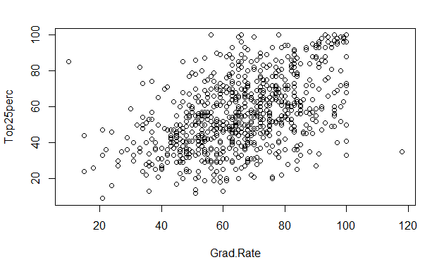

```r
plot(Grad.Rate,Top25perc)
```

Grad.Rate seems to correlate quite well with Top25perc. What about Top10perc and Top25perc?

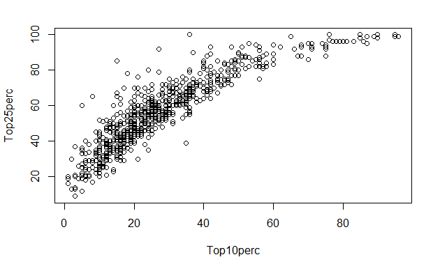

```r
plot(Top10perc,Top25perc)
```

They are multicollinear so we cannot use both of them in the model. I choose Top25percent for the model1.

```r
model1=lm(Grad.Rate~Top25perc)
summary(model1)
```

```
Call:
lm(formula = Grad.Rate ~ Top25perc)

Residuals:
    Min      1Q  Median      3Q     Max
-67.553 -10.961   0.178  10.136  61.146

Coefficients:
            Estimate Std. Error t value Pr(>|t|)
(Intercept) 42.36514    1.62089   26.14   <2e-16 ***
Top25perc    0.41397    0.02738   15.12   <2e-16 ***
---
Signif. codes:  0 ‘***’ 0.001 ‘**’ 0.01 ‘*’ 0.05 ‘.’ 0.1 ‘ ’ 1

Residual standard error: 15.1 on 775 degrees of freedom
Multiple R-squared:  0.2278,    Adjusted R-squared:  0.2268
F-statistic: 228.6 on 1 and 775 DF,  p-value: < 2.2e-16
```

It seems that Top25perc fits well in the model. Let’s try another factor, perc.alumni - how does it look like when plotted with Grad.Rate?

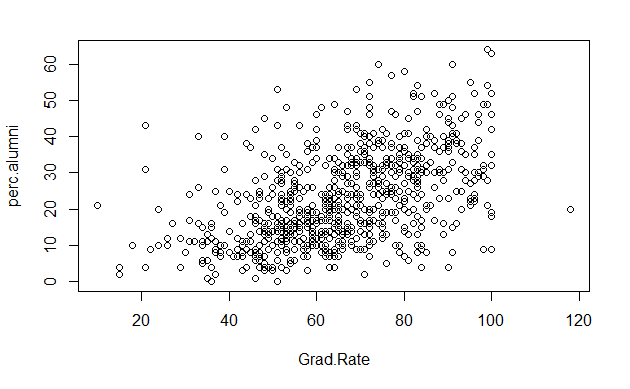

```r
plot(Grad.Rate,perc.alumni)
```

It could be in our model as well. But what about Top25percent and perc.alumni, are they correlated?

```r
cor(Top25perc,perc.alumni)
```

```
[1] 0.4178643
```

The correlation is quite high. Let’s plot the two.

[figure not shown]

```r
summary(model2)
```

```
Call:
lm(formula = Grad.Rate ~ Top25perc + perc.alumni)

Residuals:
    Min      1Q  Median      3Q     Max
-62.962  -9.011  -0.255   8.725  59.827

Coefficients:
            Estimate Std. Error t value Pr(>|t|)
(Intercept) 38.37307    1.55369   24.70   <2e-16 ***
Top25perc    0.28599    0.02807   10.19   <2e-16 ***
perc.alumni  0.48950    0.04487   10.91   <2e-16 ***
---
Signif. codes:  0 ‘***’ 0.001 ‘**’ 0.01 ‘*’ 0.05 ‘.’ 0.1 ‘ ’ 1

Residual standard error: 14.07 on 774 degrees of freedom
Multiple R-squared:  0.3307,    Adjusted R-squared:  0.329
F-statistic: 191.2 on 2 and 774 DF,  p-value: < 2.2e-16
```

Both Top25perc and perc.alumni are highly significant in the model. Let’s try adding the third independent variable into the model. Let’s add Expend. At first, let’s plot it with Grad.Rate.

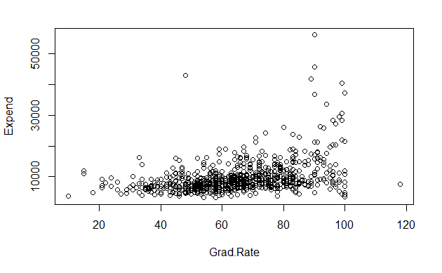

This does not seem convincing. What about Accept/Apps?

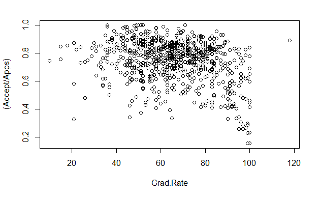

There seems to be a slight inverse correlation. Let’s add Accept/Apps to the model to see what happens. There should not be any multicollinearity issues as the correlation is to the other direction.

```r
summary(model3)
```

```
Call:
lm(formula = Grad.Rate ~ Top25perc + perc.alumni + (Accept/Apps))

Residuals:
    Min      1Q  Median      3Q     Max
-62.945  -8.737  -0.287   8.429  58.934

Coefficients:
              Estimate Std. Error t value Pr(>|t|)
(Intercept)  3.800e+01  1.598e+00  23.777   <2e-16 ***
Top25perc    2.690e-01  3.009e-02   8.939   <2e-16 ***
perc.alumni  5.126e-01  4.728e-02  10.843   <2e-16 ***
Accept       4.213e-04  3.692e-04   1.141    0.254
Accept:Apps -3.885e-09  1.520e-08  -0.255    0.798
---
Signif. codes:  0 ‘***’ 0.001 ‘**’ 0.01 ‘*’ 0.05 ‘.’ 0.1 ‘ ’ 1

Residual standard error: 14.07 on 772 degrees of freedom
Multiple R-squared:  0.3329,    Adjusted R-squared:  0.3294
F-statistic: 96.29 on 4 and 772 DF,  p-value: < 2.2e-16
```

The added value is not significant. Thus, model two with Top25perc and perc.alumni is the best model found so far, with Multiple R-squared: 0.3307 and Adjusted R-squared: 0.329.